# Radziwill

jcb

14 mai 2015

# Cours de statistiques de Nicole Radziwill

Utilise pour des TP en groupe des paquets de [M&M’s](http://fr.wikipedia.org/wiki/M%26M%27s). Chaque étudiant dispose d’un paquet dont il détermine pour chaque friandise, le nombre et les éventuelles anomalies. Les résultats sont accessibles sur github:

```r
library(RCurl)
library(qcc) # pour pareto
library(waffle) # pour waffle
# chargement initial des données qui seront stockées en interne pour un usage hors ligne.
# url <- "https://raw.githubusercontent.com/NicoleRadziwill/Data-for-R-Examples/master/mnm-clean.csv"
# x <- getURL(url, ssl.verifypeer = FALSE)
# mnms <- read.csv(text = x)
# names(mnms)
# write.csv(mnms, file = "mnms.csv") # sauvegarde

mnms <- read.csv("mnms.csv") # dataframe mnms
head(mnms)
```

```
##   X  student id color defect
## 1 1 wilburld  1     B      L
## 2 2 wilburld  2     B      N
## 3 3 wilburld  3     B      N
## 4 4 wilburld  4     B      N
## 5 5 wilburld  5     B      N
## 6 6 wilburld  6     B      C
```

```r
names(mnms)
```

```
## [1] "X"       "student" "id"      "color"   "defect"
```

```r
summary(mnms)
```

```
##        X            student          id        color    defect
##  Min.   :   1   bishopsm: 59   Min.   : 1.00   B :348   C:328
##  1st Qu.: 312   slatermr: 58   1st Qu.:14.00   BR:155   L: 87
##  Median : 623   burtonba: 57   Median :28.00   G :152   M: 71
##  Mean   : 623   corrybc : 57   Mean   :27.62   O :315   N:759
##  3rd Qu.: 934   fox2nd  : 57   3rd Qu.:41.00   R :134
##  Max.   :1245   Torrenm : 57   Max.   :59.00   Y :141
##                 (Other) :900
```

```r
str(mnms)
```

```
## 'data.frame':    1245 obs. of  5 variables:
##  $ X      : int  1 2 3 4 5 6 7 8 9 10 ...
##  $ student: Factor w/ 23 levels "bishopsm","burtonba",..: 22 22 22 22 22 22 22 22 22 22 ...
##  $ id     : int  1 2 3 4 5 6 7 8 9 10 ...
##  $ color  : Factor w/ 6 levels "B","BR","G","O",..: 1 1 1 1 1 1 1 1 1 1 ...
##  $ defect : Factor w/ 4 levels "C","L","M","N": 2 4 4 4 4 1 4 1 2 4 ...
```

Le nombre de m&m est-ille même dans chaque paquet ?

```r
n.student <- table(mnms$student)
sum(n.student)
```

```
## [1] 1245
```

```r
n.student
```

```
##
## bishopsm burtonba CHIPIWKB  corrybc   fox2nd gallagej gentilns Gibbontp
##       59       57       51       57       57       56       52       54
## Howarden hyltonem mayianmm  Mooreto Potterba scholbmj slatermr smith2ak
##       52       53       52       56       51       53       58       54
## smith8jd  soykaan  Torrenm vanarstx   wadehp wilburld  WINESHM
##       49       53       57       53       56       53       52
```

```r
sd(n.student)
```

```
## [1] 2.633773
```

```r
summary(as.numeric(n.student))
```

```
##    Min. 1st Qu.  Median    Mean 3rd Qu.    Max.
##   49.00   52.00   53.00   54.13   56.50   59.00
```

## Histogramme

```r
t <- table(mnms$student)
t
```

```
##
## bishopsm burtonba CHIPIWKB  corrybc   fox2nd gallagej gentilns Gibbontp
##       59       57       51       57       57       56       52       54
## Howarden hyltonem mayianmm  Mooreto Potterba scholbmj slatermr smith2ak
##       52       53       52       56       51       53       58       54
## smith8jd  soykaan  Torrenm vanarstx   wadehp wilburld  WINESHM
##       49       53       57       53       56       53       52
```

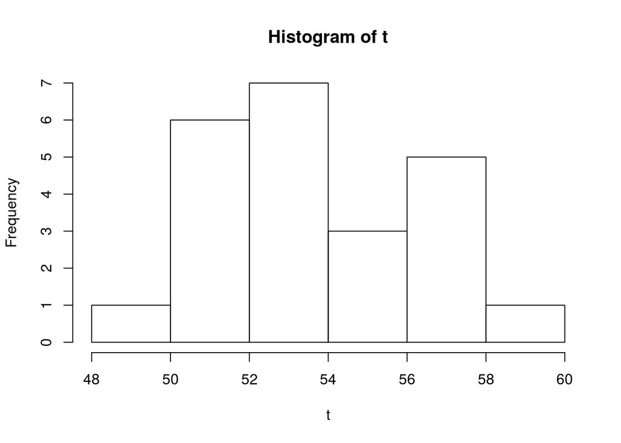

```r
hist(t)
```

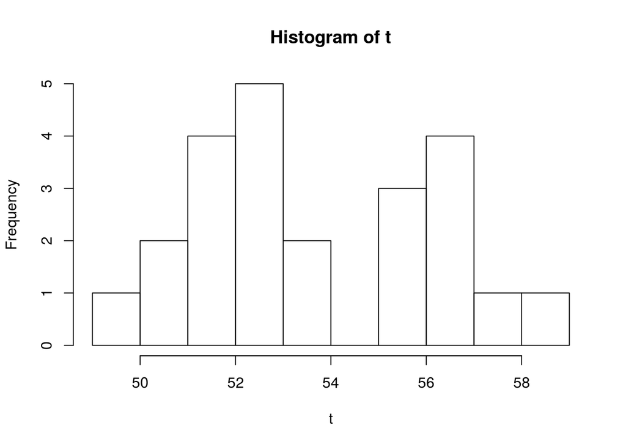

```r
hist(t, breaks = 10)
```

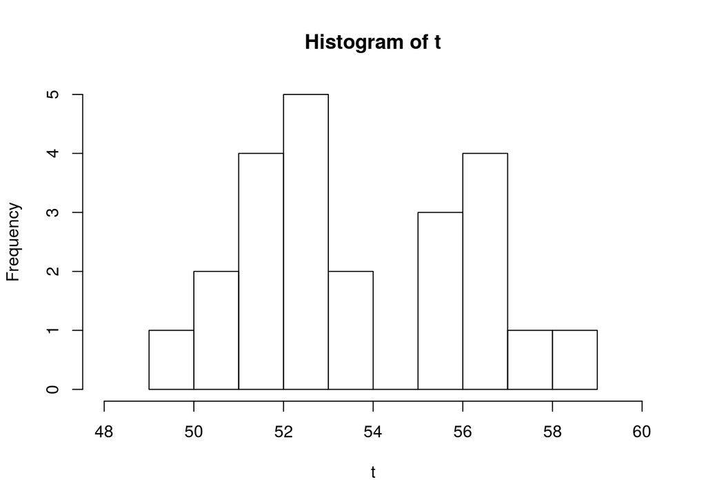

```r
hist(t, breaks = 10, xlim = c(48,60))
```

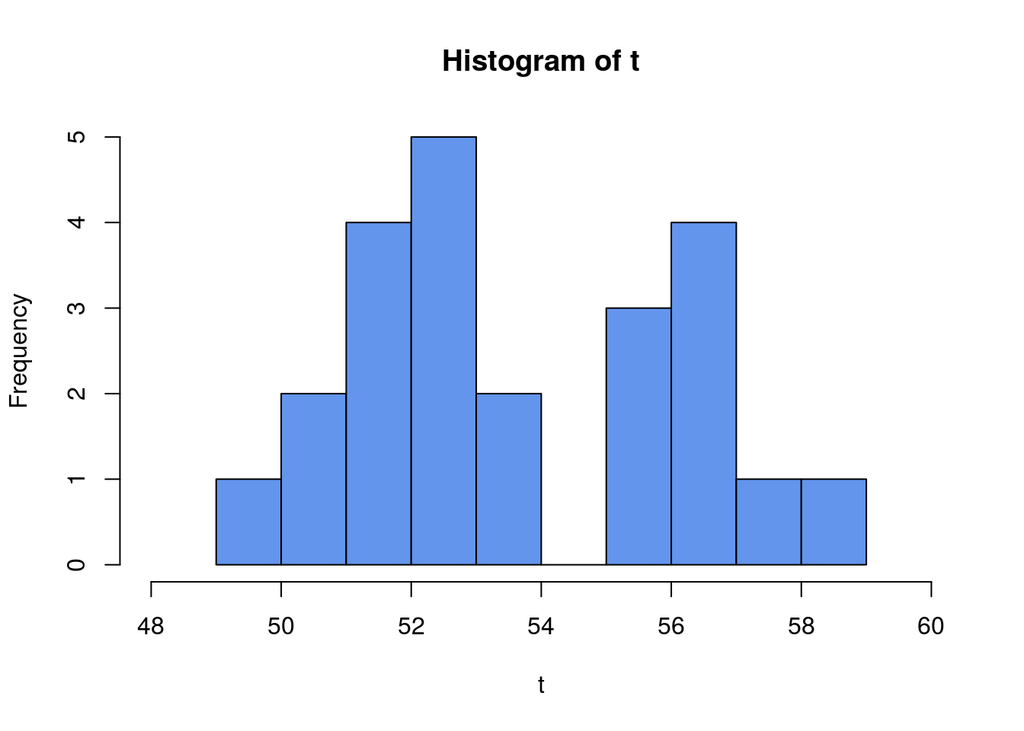

```r
hist(t, breaks = 10, xlim = c(48,60), col = "cornflowerblue")
```

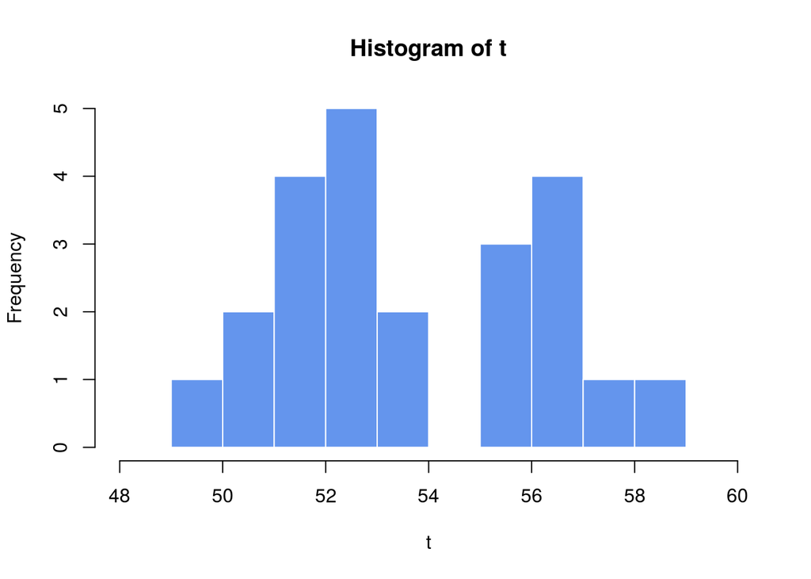

```r
hist(t, breaks = 10, xlim = c(48,60), col = "cornflowerblue", border = "white")
```

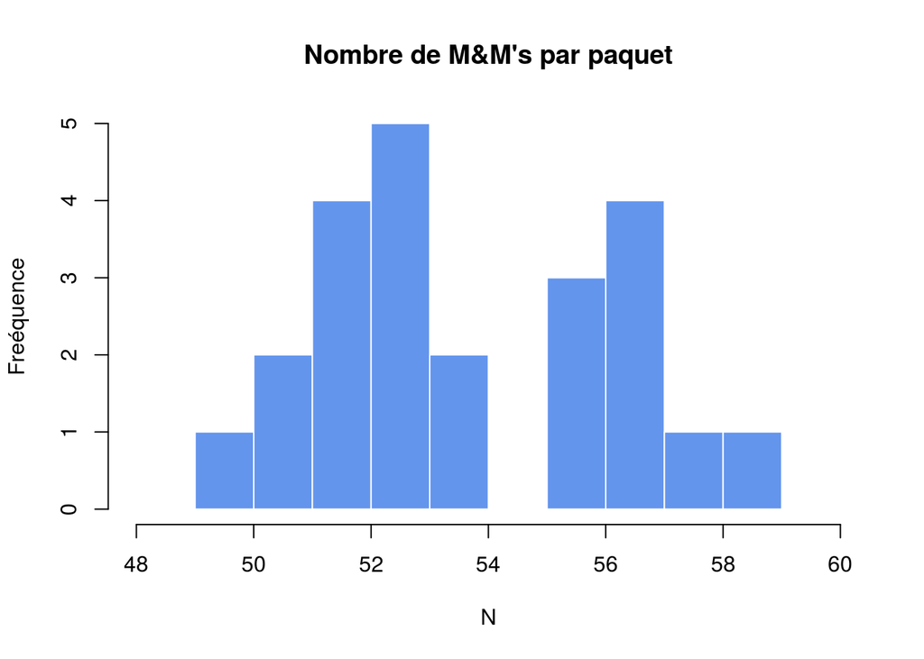

```r
hist(t, breaks = 10, xlim = c(48,60), col = "cornflowerblue", border = "white", main = "Nombre de M&M's par paquet", xlab = "N", ylab = "Freéquence")
```

## Pie et Waffle chart (p 118)

```r
mm.counts <- as.vector(table(mnms$color))
names(mm.counts) <- c("blue","brown","green","orange","red","yellow")
mm.counts
```

```
##   blue  brown  green orange    red yellow
##    348    155    152    315    134    141
```

```r
percents <- round(mm.counts/sum(mm.counts)*100)
my.labels <- paste(names(mm.counts), " ", percents, "%", sep = "")
my.labels
```

```
## [1] "blue 28%"   "brown 12%"  "green 12%"  "orange 25%" "red 11%"
## [6] "yellow 11%"
```

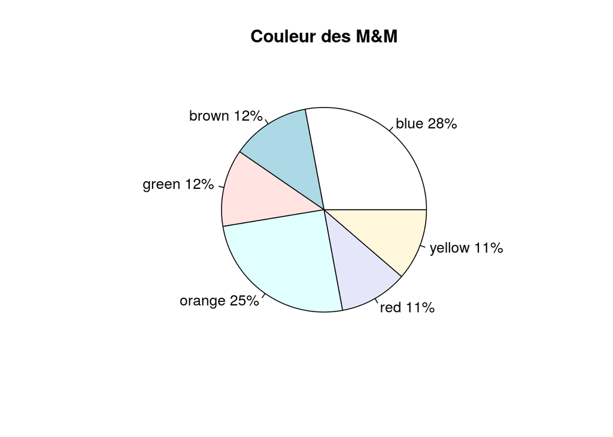

```r
pie(mm.counts, labels = my.labels, main = "Couleur des M&M")
```

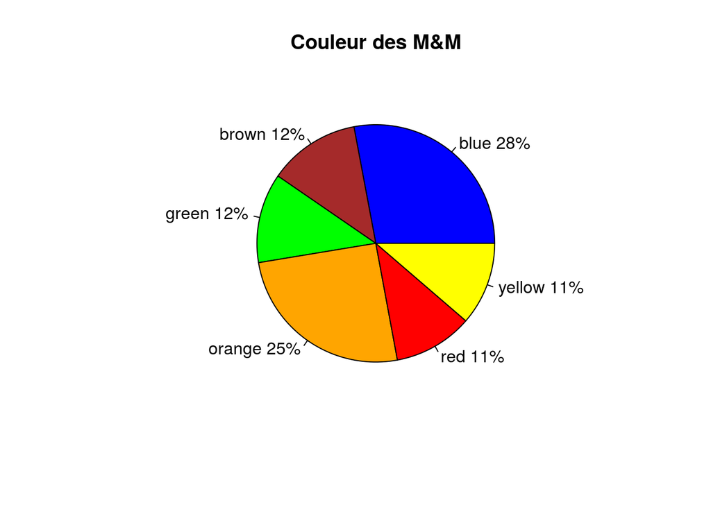

```r
pie(mm.counts, labels = my.labels, main = "Couleur des M&M", col = names(mm.counts))
```

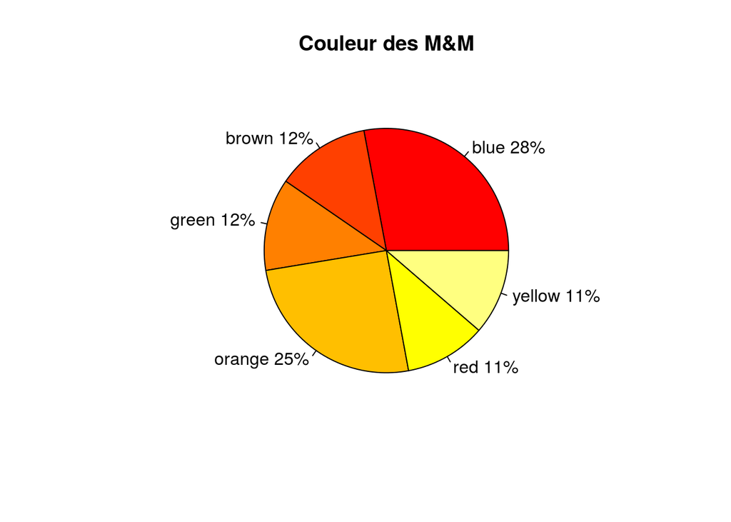

```r
pie(mm.counts, labels = my.labels, main = "Couleur des M&M", col = heat.colors(length(mm.counts)))
```

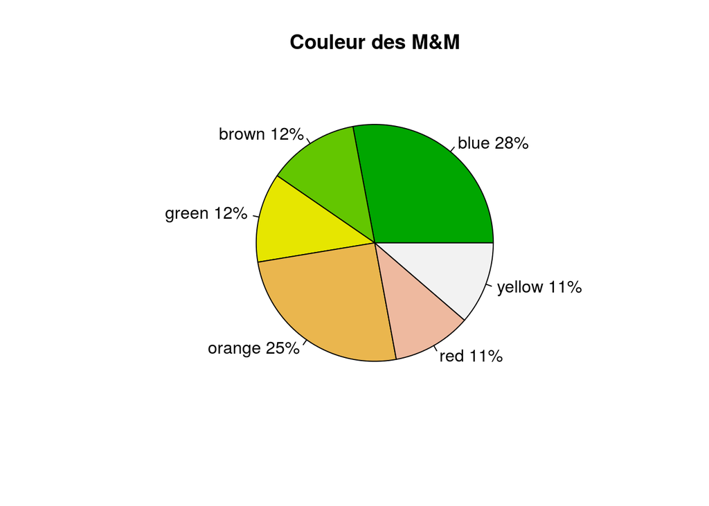

```r
pie(mm.counts, labels = my.labels, main = "Couleur des M&M", col = terrain.colors(length(mm.counts)))
```

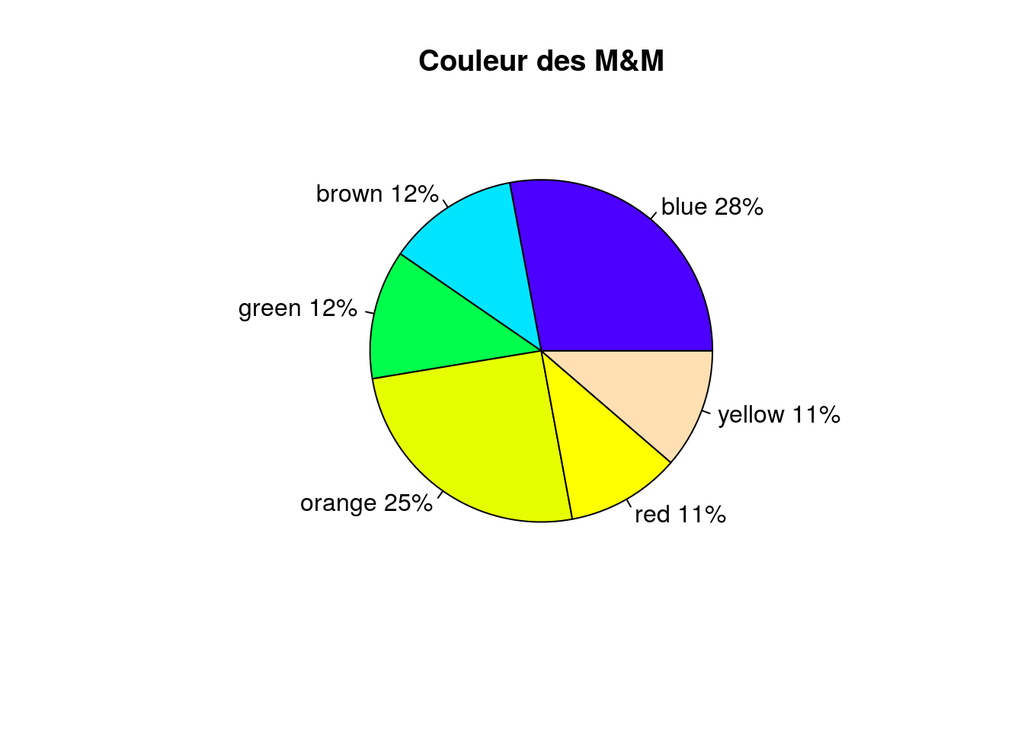

```r
pie(mm.counts, labels = my.labels, main = "Couleur des M&M", col = topo.colors(length(mm.counts)))
```

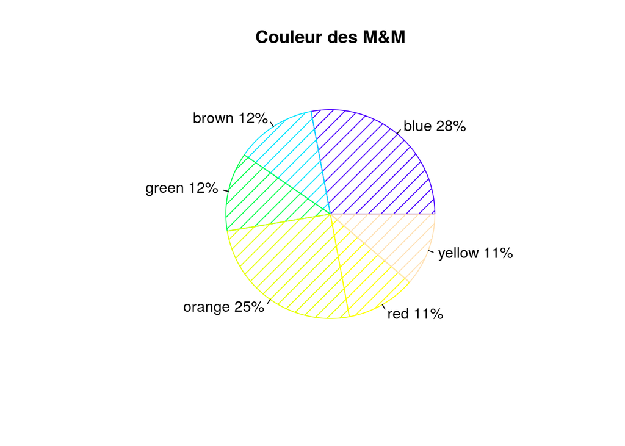

```r
pie(mm.counts, labels = my.labels, main = "Couleur des M&M", col = topo.colors(length(mm.counts)), density = 10)
```

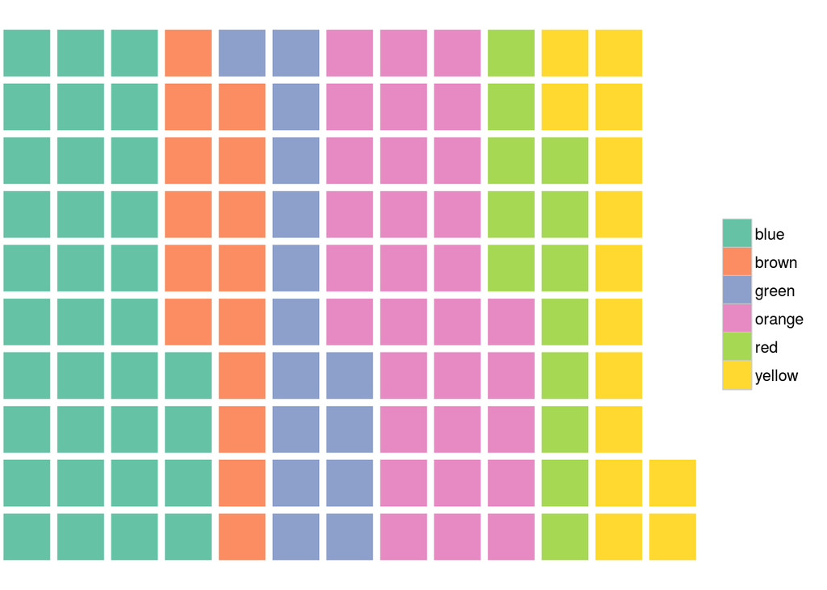

```r
waffle(mm.counts/10)
```

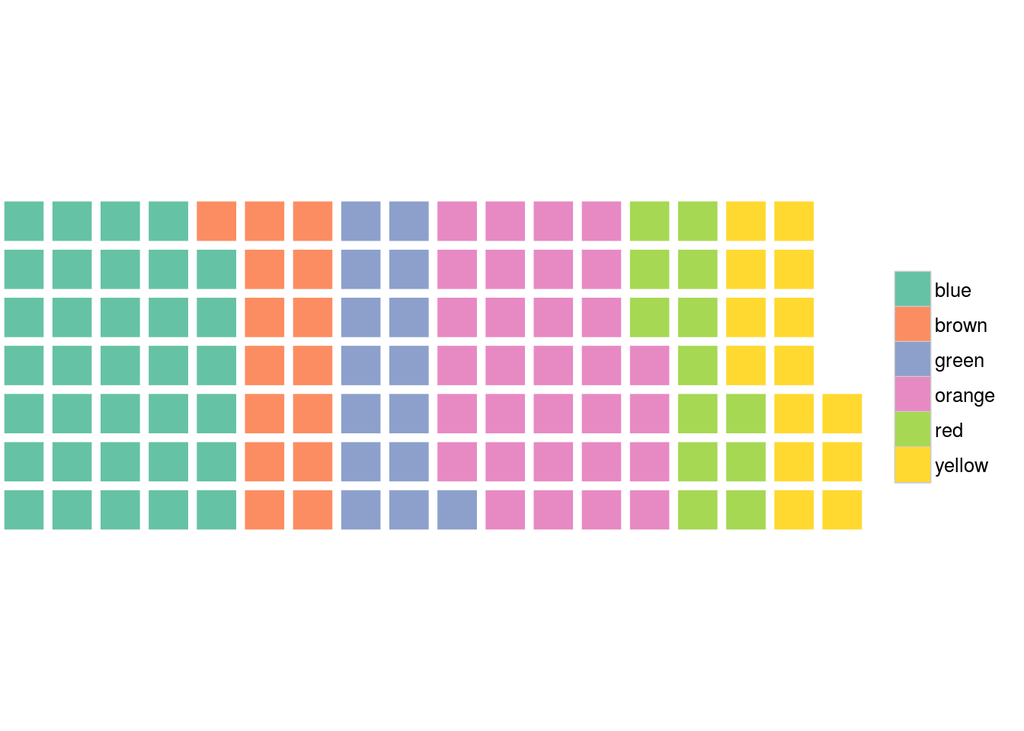

```r
waffle(mm.counts/10, rows = 7)
```

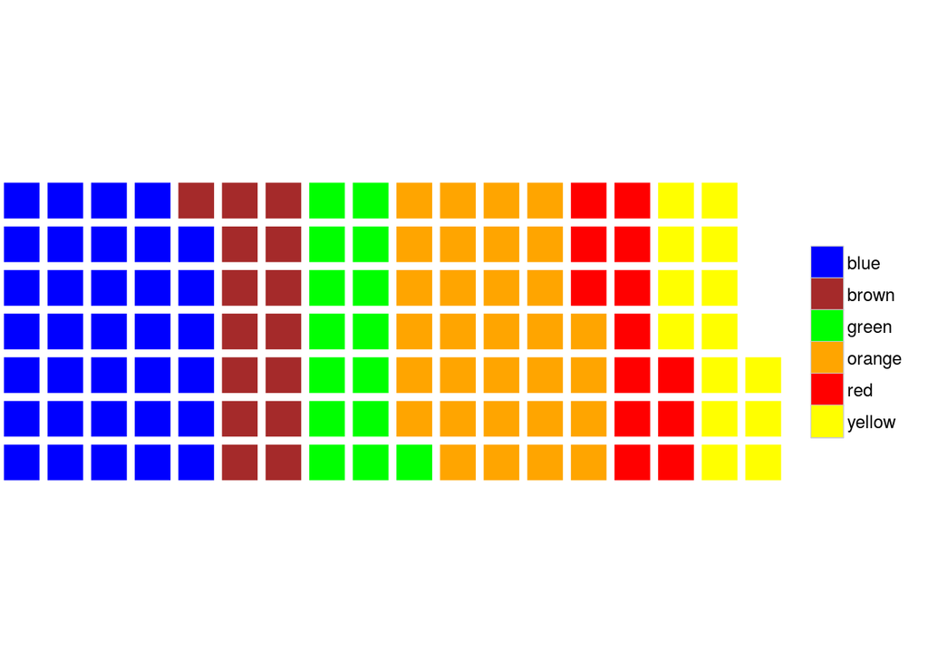

```r
waffle(mm.counts/10, rows = 7, colors = names(mm.counts))
```

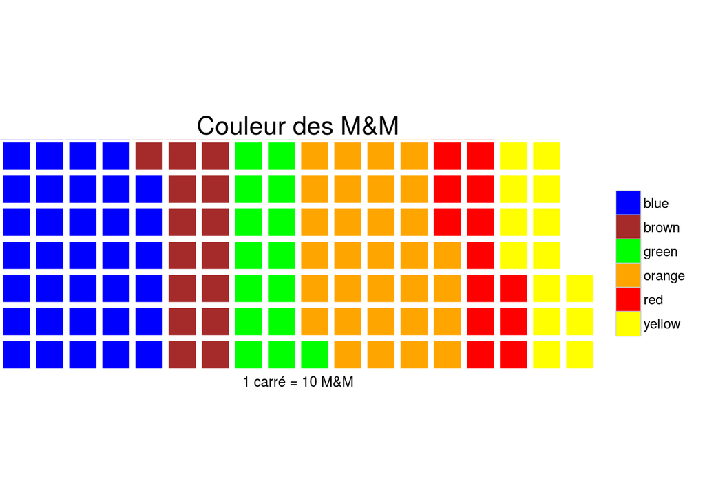

```r
waffle(mm.counts/10, rows = 7, colors = names(mm.counts), title = "Couleur des M&M", xlab = "1 carré = 10 M&M")
```

## Diagramme de Pareto (p.125)

Le diagramme de Pareto (DP) permet de représenter une variable catégorielle dont on connait la fréquence de chaque catégories (comme la couleur). Les fréquences sont triées par ordre décroissant et représentées de la gauche vers la droite sous forme d’un graphique en barre surmonté d’une courbe représentant les fréquences cumulées. A partir des fréquences cumulées il est aisé d’identifier les catégories responsables de 80% de l’effet. Selon la loi de Pareto, 20% des catégories sont responsables de 80% de l’effet. On peut ainsi séparer les “vital few” des “trivial many” (arbres de défaillance).

Exemple: cause des retards en cours des étudiants.

```r
defect.counts <- c(12,29,18,3, 34,4)
names(defect.counts) <- c("Météo","Sommeil","Réveil","Changement Horaire","Circulation","Autre")
defect.counts
```

```
##              Météo            Sommeil             Réveil
##                 12                 29                 18
## Changement Horaire        Circulation              Autre
##                  3                 34                  4
```

```r
df.defects <- data.frame(defect.counts)
df.defects
```

```
##                    defect.counts
## Météo                         12
## Sommeil                       29
## Réveil                        18
## Changement Horaire             3
## Circulation                   34
## Autre                          4
```

Le diagramme de Pareto nécessite uniquement un vecteur des fréquences:

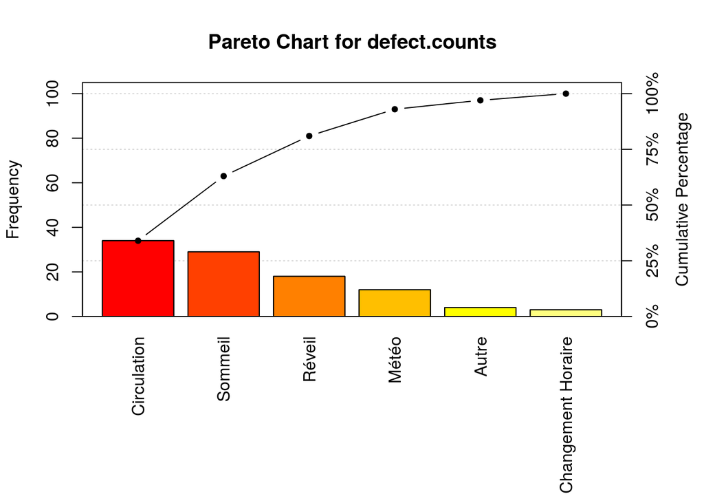

```r
p <- pareto.chart(defect.counts)
```

```r
p
```

```
##
## Pareto chart analysis for defect.counts
##                      Frequency Cum.Freq. Percentage Cum.Percent.
##   Circulation               34        34         34           34
##   Sommeil                   29        63         29           63
##   Réveil                    18        81         18           81
##   Météo                     12        93         12           93
##   Autre                      4        97          4           97
##   Changement Horaire         3       100          3          100
```

```r
colnames(p) <- c("Fréquence","Fréq.Cum.","Pourcentage","Pourc.Cum.")
p
```

```
##
## Pareto chart analysis for defect.counts
##                      Fréquence Fréq.Cum. Pourcentage Pourc.Cum.
##   Circulation               34        34          34         34
##   Sommeil                   29        63          29         63
##   Réveil                    18        81          18         81
##   Météo                     12        93          12         93
##   Autre                      4        97           4         97
##   Changement Horaire         3       100           3        100
```

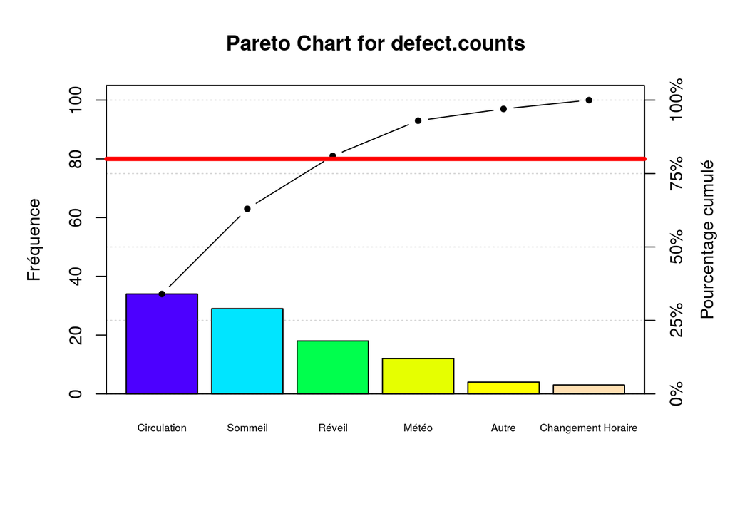

```r
p <- pareto.chart(defect.counts, ylab = "Fréquence", ylab2 = "Pourcentage cumulé", las = 1, cex.names = 0.6, col=topo.colors(6))
abline(h = (sum(defect.counts) * 0.8), col = "red", lwd = 4)
```

Trois causes expliquent 80% des retards. Pour explorer ces raisons on peut utiliser le diagramme d’[Ishikawa](http://fr.wikipedia.org/wiki/Diagramme_de_causes_et_effets) (existe dans le package qqc).